# Unsupervised clustering

# Fanny

Fuzzy Analysis Clustering

## iris

```r
fanny1 <- fanny(iris.var, k = 3, diss = F)
fanny1
```

```
## Fuzzy Clustering object of class 'fanny' :
## m.ship.expon.        2
## objective     45.07716
## tolerance        1e-15
## iterations          28
## converged            1
## maxit              500
## n                  150
## Membership coefficients (in %, rounded):
##        [,1] [,2] [,3]
##   [1,]   91    4    5
##   [2,]   86    6    8
##   [3,]   87    5    8
##   [4,]   84    7    9
##   [5,]   90    4    6
```

[output cut: 159 more lines]

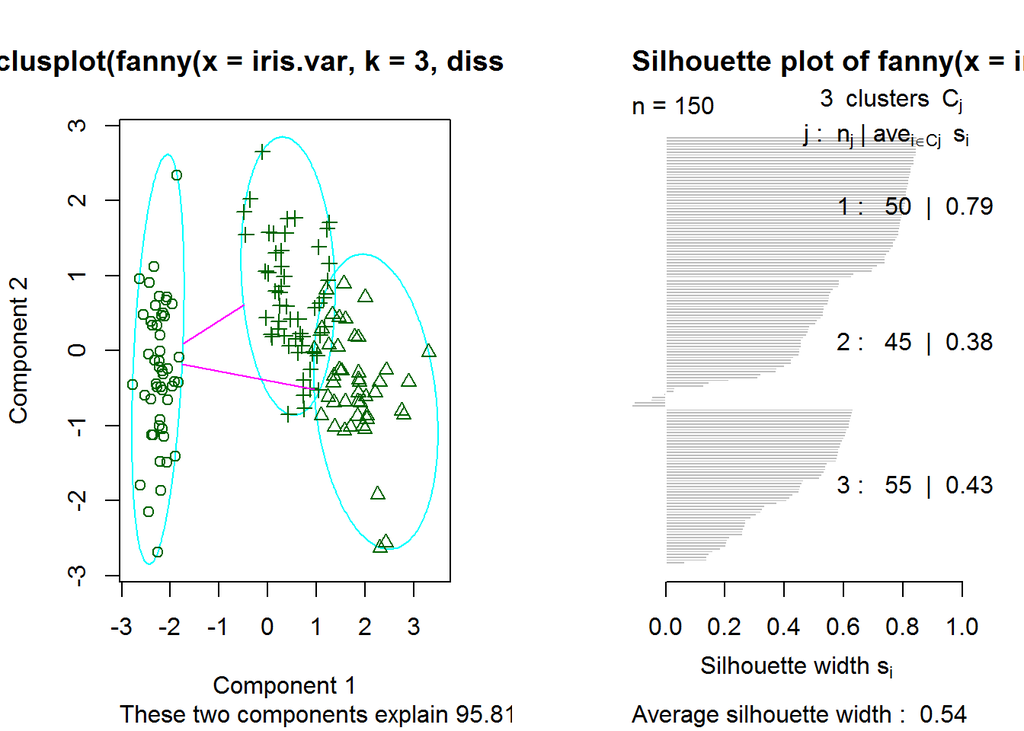

```r
par(mfrow = c(1,2))
plot(fanny1)
```

One group well differenciated More difficult for the others

### Plot membership

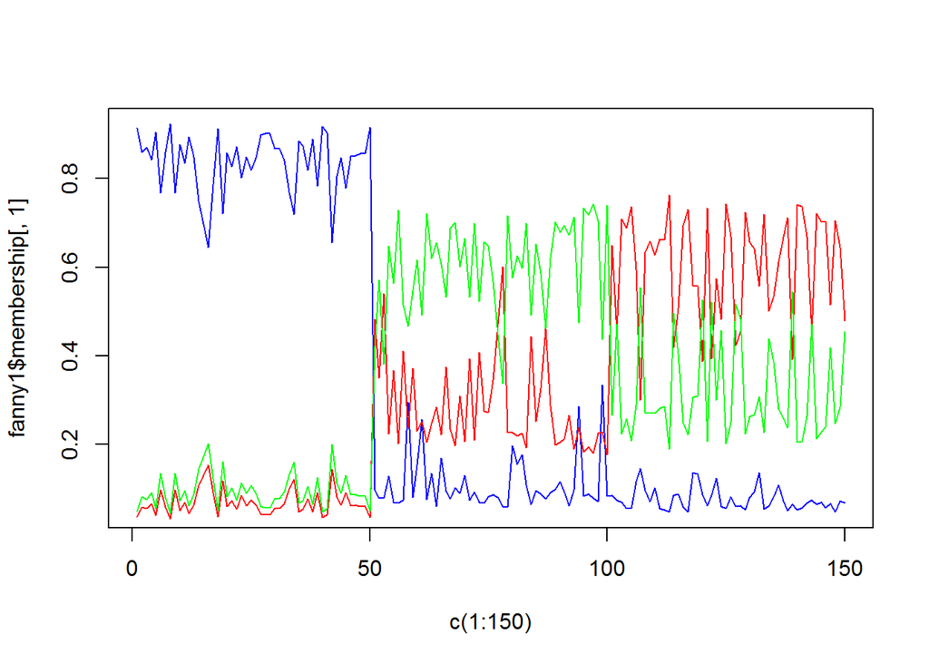

```r
par(mfrow = c(1,1))
plot(c(1:150), fanny1$membership[,1], type = "l", col = "blue")
lines(c(1:150), fanny1$membership[,2], type = "l", col = "red")
lines(c(1:150), fanny1$membership[,3], type = "l", col = "green")
```

See the probability of an individual to be in a cluster

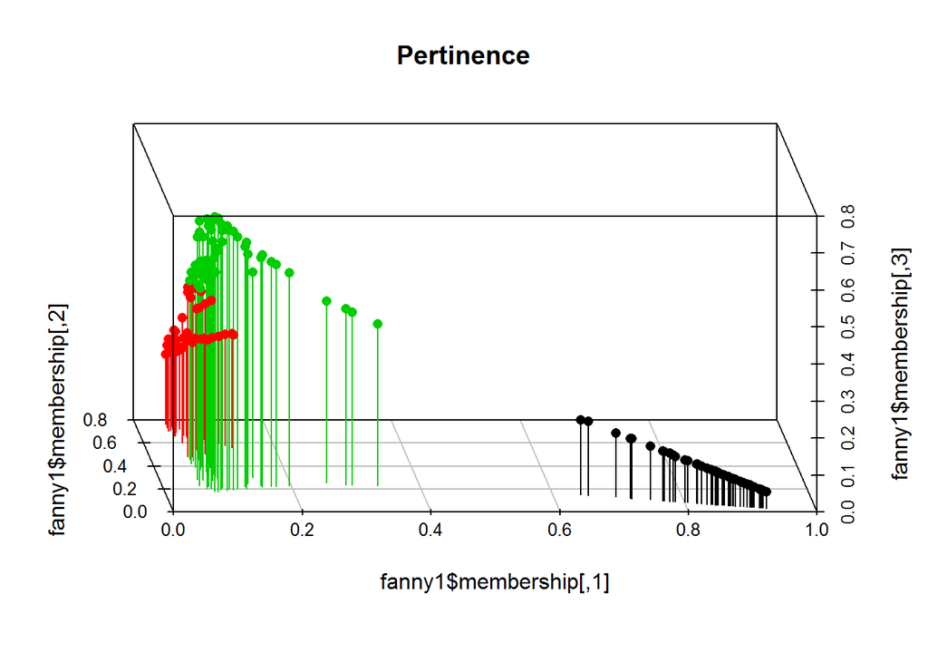

```r
s3d <- scatterplot3d(fanny1$membership, color = fanny1$cluster, type = "h", angle = 100, scale.y = 0.7, pch = 16, main = "Pertinence")
```

```r
plot3d(fanny1$membership, col = fanny1$cluster)
```

3D representations

## Doubs

```r
fanny2 <- fanny(spe.norm, k = 4, diss = F)
fanny2
```

```
## Fuzzy Clustering object of class 'fanny' :
## m.ship.expon.        2
## objective     3.353078
## tolerance        1e-15
## iterations         142
## converged            1
## maxit              500
## n                   29
## Membership coefficients (in %, rounded):
##    [,1] [,2] [,3] [,4]
## 1    30   23   30   17
## 2    37   16   37   10
## 3    38   15   38    9
## 4    36   18   36   11
## 5    24   30   24   22
## 6    34   20   34   12
## 7    38   15   38    9
## 9    25   30   25   21
## 10   32   22   32   13
## 11   36   18   36   11
## 12   38   15   38    9
## 13   35   18   35   11
## 14   35   18   35   12
## 15   32   22   32   13
## 16   28   27   28   17
## 17   25   31   25   19
## 18   21   34   21   23
## 19   20   34   20   27
## 20   13   30   13   44
## 21   10   23   10   56
## 22   11   23   11   55
## 23   21   32   21   26
## 24   19   32   19   29
## 25   19   32   19   29
## 26   12   25   12   52
## 27   11   22   11   56
## 28   11   23   11   54
## 29   12   24   12   52
## 30   14   26   14   47
## Fuzzyness coefficients:
## dunn_coeff normalized
## 0.30196475 0.06928633
## Closest hard clustering:
##  1  2  3  4  5  6  7  9 10 11 12 13 14 15 16 17 18 19 20 21 22 23 24 25 26
##  1  1  1  1  2  1  1  2  3  1  1  1  1  3  3  2  2  2  4  4  4  2  2  2  4
## 27 28 29 30
##  4  4  4  4
##
## Available components:
##  [1] "membership"  "coeff"       "memb.exp"    "clustering"  "k.crisp"
##  [6] "objective"   "convergence" "diss"        "call"        "silinfo"
## [11] "data"
```

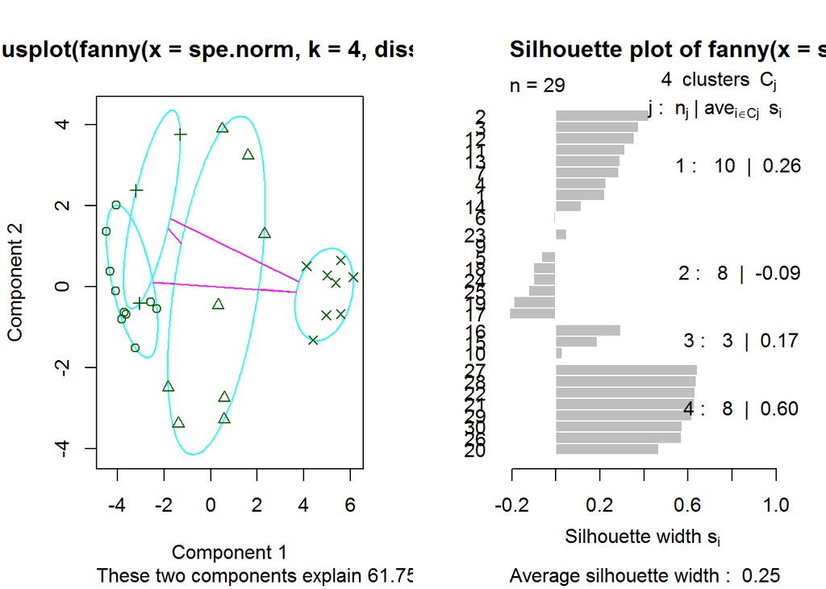

```r
par(mfrow = c(1,2))
plot(fanny2)
```

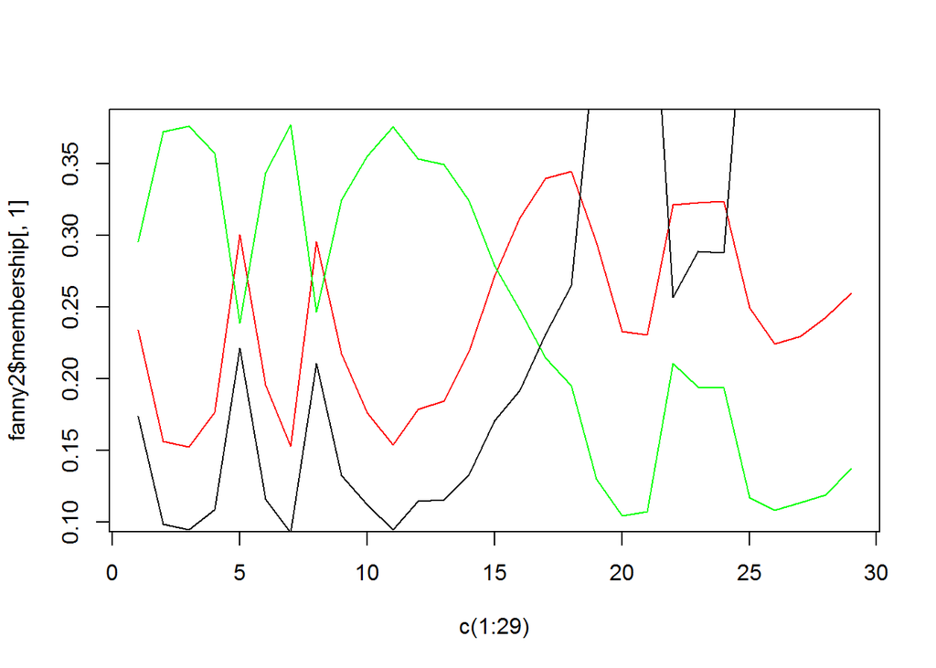

```r
par(mfrow = c(1,1))
plot(c(1:29), fanny2$membership[,1], type = "l", col = "blue")
lines(c(1:29), fanny2$membership[,2], type = "l", col = "red")
lines(c(1:29), fanny2$membership[,3], type = "l", col = "green")
lines(c(1:29), fanny2$membership[,4], type = "l", col = "black")
```

```r
plot3d(fanny2$membership, col = fanny2$cluster, type = "s")
```

### Plot of the 4 Fanny clusters on a map of the Doubs rive

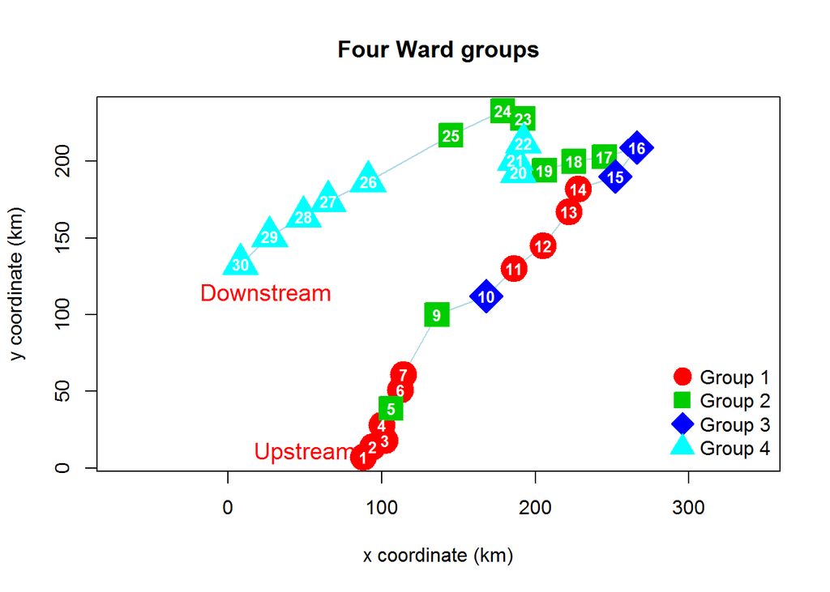

```r
cluster_map(spa, fanny2$cluster)
```

# Cmeans

Fuzzy version of kmeans

## Iris

```r
cmeans1 <- cmeans(iris.var, 3 , 50)
cmeans1
```

```
## Fuzzy c-means clustering with 3 clusters
##
## Cluster centers:
##   Sepal.Length Sepal.Width Petal.Length Petal.Width
## 1     5.003966    3.414092     1.482810   0.2535439
## 2     5.888865    2.761045     4.363854   1.3972646
## 3     6.774930    3.052359     5.646681   2.0535077
##
## Memberships:
##                  1            2            3
##   [1,] 0.996623592 0.0023043875 0.0010720201
##   [2,] 0.975850782 0.0166508306 0.0074983870
##   [3,] 0.979824775 0.0137603625 0.0064148626
##   [4,] 0.967425113 0.0224667859 0.0101081009
##   [5,] 0.994470314 0.0037617567 0.0017679294
```

[output cut: 156 more lines]

```r
cmeans1$membership
```

```
##                  1            2            3
##   [1,] 0.996623592 0.0023043875 0.0010720201
##   [2,] 0.975850782 0.0166508306 0.0074983870
##   [3,] 0.979824775 0.0137603625 0.0064148626
##   [4,] 0.967425113 0.0224667859 0.0101081009
##   [5,] 0.994470314 0.0037617567 0.0017679294
##   [6,] 0.934570344 0.0448089936 0.0206206623
##   [7,] 0.979490476 0.0140047078 0.0065048165
##   [8,] 0.999547231 0.0003115563 0.0001412130
##   [9,] 0.930375344 0.0477211462 0.0219035094
##  [10,] 0.982721634 0.0119364708 0.0053418951
##  [11,] 0.968040671 0.0217579618 0.0102013673
##  [12,] 0.992136499 0.0054322721 0.0024312285
##  [13,] 0.970638153 0.0201841797 0.0091776669
##  [14,] 0.922965855 0.0517971275 0.0252370171
```

[output cut: 136 more lines]

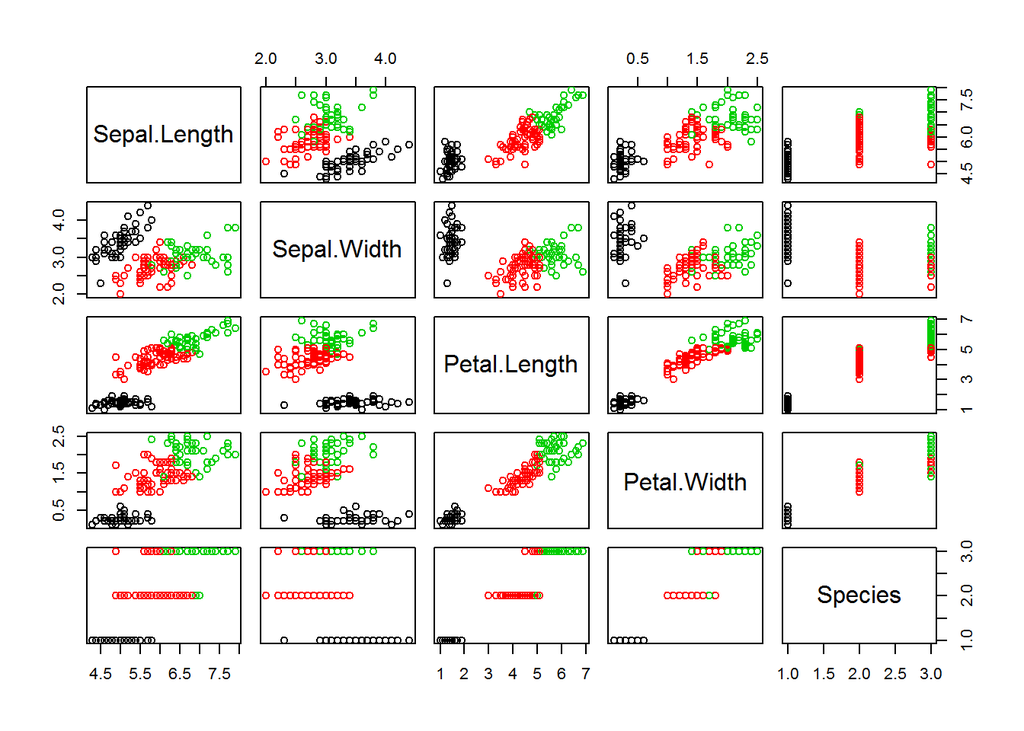

```r
plot3d(cmeans1$membership, col = cmeans1$cluster, type = "p")

plot(iris, col = cmeans1$cluster)
```

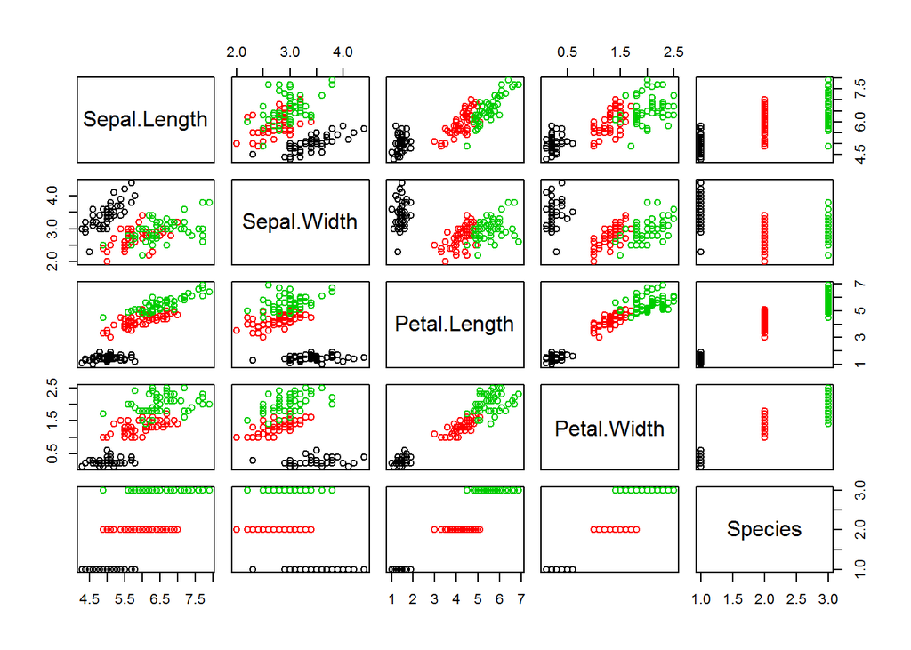

```r
plot(iris, col = iris$Species)
```

Compare the cluster with the real species

## Doubs

```r
cmeans2 <- cmeans(spe.norm, 4 , 50)
cmeans2
```

```
## Fuzzy c-means clustering with 4 clusters
##
## Cluster centers:
##          Cogo       Satr       Phph       Neba        Thth        Teso
## 1 0.002693542 0.01791140 0.04127882 0.08571413 0.008986555 0.011871548
## 2 0.005447615 0.03201821 0.03513021 0.04786396 0.005150975 0.008518298
## 3 0.106626585 0.26626610 0.35953726 0.40604908 0.071761136 0.176629745
## 4 0.094268063 0.56302282 0.52577233 0.44494842 0.107187106 0.047690856
##          Chna        Chto       Lele       Lece       Baba        Spbi
## 1 0.105118152 0.098129572 0.14714636 0.20337037 0.23586958 0.124879641
## 2 0.061294720 0.014563231 0.06647944 0.32156769 0.01784897 0.014397038
## 3 0.033853666 0.158355950 0.24152440 0.22289428 0.13844583 0.110640651
## 4 0.001518069 0.005643681 0.04247839 0.09818745 0.01348859 0.004018632
##         Gogo       Eslu       Pefl        Rham       Legi        Scer
## 1 0.27980746 0.20250684 0.16765367 0.209902800 0.18140412 0.124194232
```

[output cut: 55 more lines]

```r
cmeans2$membership
```

```
##             1          2          3          4
## 1  0.15702468 0.17413729 0.25642173 0.41241630
## 2  0.03007461 0.03259237 0.09732272 0.84001030
## 3  0.02997425 0.03161114 0.10842854 0.82998606
## 4  0.06330036 0.06036804 0.25004060 0.62629101
## 5  0.25144734 0.18323797 0.37147483 0.19383986
## 6  0.07819440 0.07423849 0.39447301 0.45309410
## 7  0.03157949 0.03426074 0.13265006 0.80150971
## 9  0.21122647 0.26730366 0.32004254 0.20142732
## 10 0.09408040 0.10048416 0.43578857 0.36964688
## 11 0.05922313 0.06669223 0.18730078 0.68678387
## 12 0.02890421 0.03186143 0.11014856 0.82908580
## 13 0.06708198 0.07296698 0.21687357 0.64307747
## 14 0.07404213 0.07688354 0.29380244 0.55527189
## 15 0.08327071 0.08166831 0.53378416 0.30127682
## 16 0.10793983 0.08866615 0.63374397 0.16965005
## 17 0.14759808 0.10684678 0.59691016 0.14864497
## 18 0.25041126 0.14475741 0.47107184 0.13375949
## 19 0.34764940 0.18648188 0.34028005 0.12558868
## 20 0.72216055 0.13367339 0.09888224 0.04528382
## 21 0.89934574 0.04806771 0.03490405 0.01768249
## 22 0.88415595 0.05535068 0.04000469 0.02048869
## 23 0.09760713 0.77604130 0.07344883 0.05290274
## 24 0.09983244 0.80933581 0.05307452 0.03775722
## 25 0.20959608 0.59635419 0.11799263 0.07605710
## 26 0.76728662 0.14079677 0.05825357 0.03366304
## 27 0.86697167 0.06686206 0.04245912 0.02370716
## 28 0.85040786 0.07414140 0.04804022 0.02741052
## 29 0.85373636 0.06261641 0.05497656 0.02867066
## 30 0.76401707 0.10276629 0.08474072 0.04847591
```

```r
plot3d(cmeans2$membership, col = cmeans2$cluster, type = "s")
```

### Plot of the 4 cmeans clusters on a map of the Doubs rive

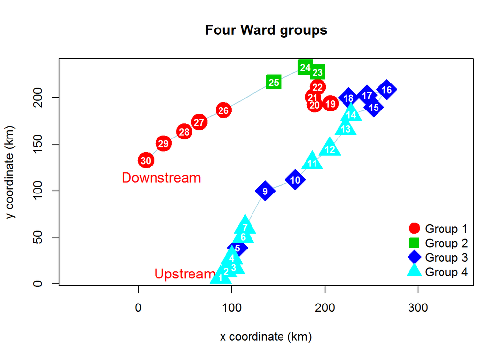

```r
cluster_map(spa, cmeans2$cluster)
```

# Clara

## Prepare data

```r
morpho <- lascaux$morpho

clara1 <- clara(lascaux$morpho, k = 5)
clara1
```

```
## Call:     clara(x = lascaux$morpho, k = 5)
## Medoids:
##         LS    MD    MAD    MAN   MPEL  MPEC   DAD     DC   DAN  DPEL  DPEC
## 247 122.90 57.49  99.78  90.92  66.58 33.43 44.69     NA 42.84    NA 35.89
## 269 143.91 64.71 114.20 108.24  79.75 38.40 51.06     NA 51.33    NA 42.19
## 88  206.37 96.86 167.95 149.14 112.05 52.35 74.86 116.26 72.32 51.38 58.71
## 276 107.58 48.03  87.29  79.50  58.19 30.52 39.67     NA 37.05    NA 30.72
## 266 164.87 77.59 131.18 121.80  91.37 43.30 55.79     NA 57.81    NA 51.89
##       ADC  ADAN ADPEL  ADPEC PECPEL PECAN   PECC PELAN  PELC   ANC  LPRO
## 247 24.23 22.49    NA  72.39  34.94    NA     NA 25.34    NA 34.31  7.99
## 269 31.21 26.68    NA  84.55  43.44    NA     NA 28.78    NA 40.65  9.69
## 88  42.83 39.75 66.47 119.86  61.46 98.15 156.53 38.71 97.75 59.99 14.49
## 276 20.06 19.38    NA  63.80  29.71    NA     NA 23.13    NA 31.69  6.77
## 266 33.56 30.57    NA  98.28  51.10    NA     NA 31.52    NA 48.25 10.57
##        DO  LPOO  LTET  HTET  LMAX   LAD    LD    HD    LC   LAN   HAN
## 247  7.33 17.63 31.71    NA 14.87  9.65 17.45 19.28 21.07 12.75 17.70
## 269  8.70 20.61 37.23    NA 16.87 11.63 19.95 22.66 23.24 14.52 19.74
## 88  13.26 29.91 55.09 29.36    NA 16.32 29.98 33.95 32.35 19.70 31.18
## 276  5.98 14.94 26.36    NA 12.29  6.14 12.96 17.04 16.96  9.13 15.04
## 266 10.17 24.89 43.97    NA 21.88 15.40 21.96 25.45 26.54 16.04 22.66
##     LPELG LPECG  HPED  ETET
## 247 15.73 20.92    NA  8.21
## 269 18.78 25.94    NA  9.51
## 88  34.78 40.49 20.92 15.66
## 276 13.75 18.82    NA  7.29
## 266 21.39 29.37    NA 13.14
## Objective function:   17.34635
## Clustering vector:    Named int [1:306] 1 2 1 2 3 1 4 1 4 1 5 1 3 2 4 5 3 4 ...
##  - attr(*, "names")= chr [1:306] "1" "2" "3" "4" "5" "6" "7" ...
## Cluster sizes:            74 88 24 46 74
## Best sample:
##  [1] 5   11  18  20  21  29  35  41  46  50  62  63  66  67  81  84  85
## [18] 88  95  96  107 121 132 146 163 165 176 184 185 198 206 210 212 222
## [35] 228 234 235 244 247 253 255 261 264 266 269 274 276 279 282 305
##
## Available components:
##  [1] "sample"     "medoids"    "i.med"      "clustering" "objective"
##  [6] "clusinfo"   "diss"       "call"       "silinfo"    "data"
```

```
## Missing values were displaced by the median of the corresponding variable(s)
```

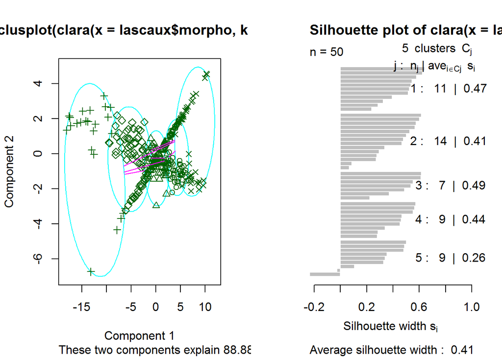

```r
par(mfrow = c(1,2))
plot(clara1)
```

```r
table(clara1$clustering)
```

```
##
##  1  2  3  4  5
## 74 88 24 46 74
```

# SOM

## Iris

SOM Tools Box better with Matlab - But R can do it too But it’s ugly - maybe#

somgrid = size of the map, normally at least 5*sqrt(n)

```r
set.seed(700) #the random number always start from this point
sqrt(150)*5 #150 individuals in Iris
```

```
## [1] 61.23724
```

```r
somiris <- som(as.matrix(iris[,1:4]), grid = somgrid(7,9,"hexagonal")) #or rectangular for less neighbors
names(somiris)
```

```
##  [1] "data"         "grid"         "codes"        "changes"
##  [5] "alpha"        "radius"       "toroidal"     "unit.classif"
##  [9] "distances"    "method"
```

### Graphics map

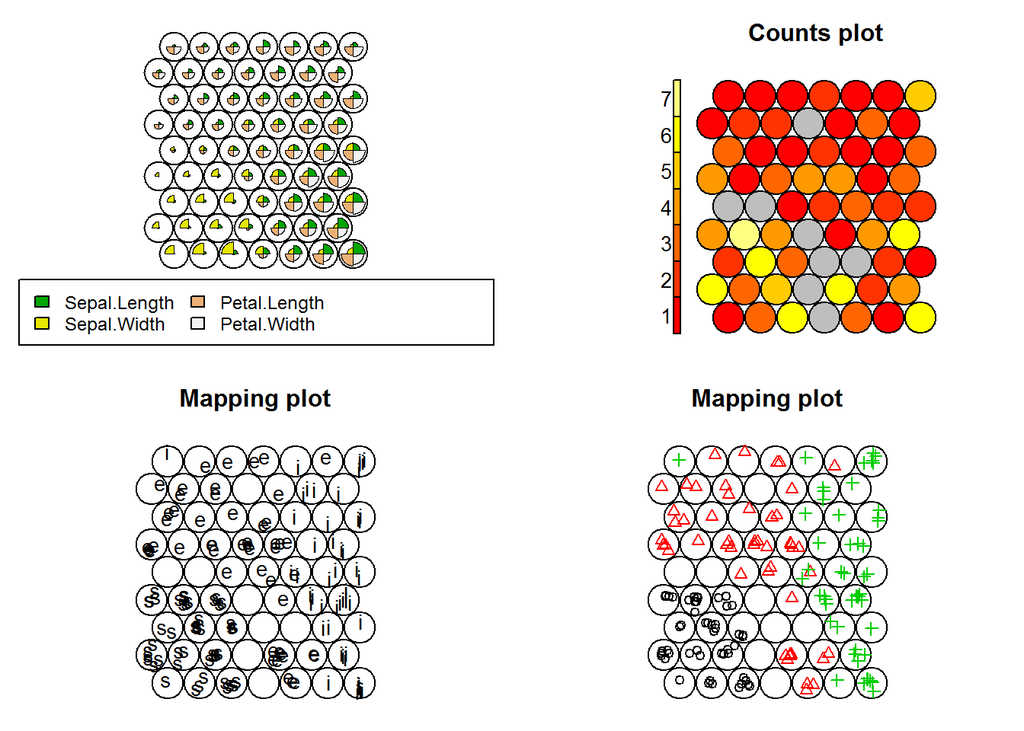

```r
par(mfrow = c(1,1))
par(mfrow = c(2,2))
plot(somiris, type = "codes")
#All flower types possible according to the data

plot(somiris, type = "counts")
#How many individuals in each flower type

labiris <- c(rep("s", 50), rep("e", 50), rep ("i", 50))
plot(somiris, type = "mapping", labels = labiris)
#Which species in each flower type

plot(somiris, type = "mapping", pch = rep(1:3, rep (50,3)), col = rep(1:3, rep (50, 3)))
```

```r
#Other representation of the species
```

### Plot a dendrogram with Ward method

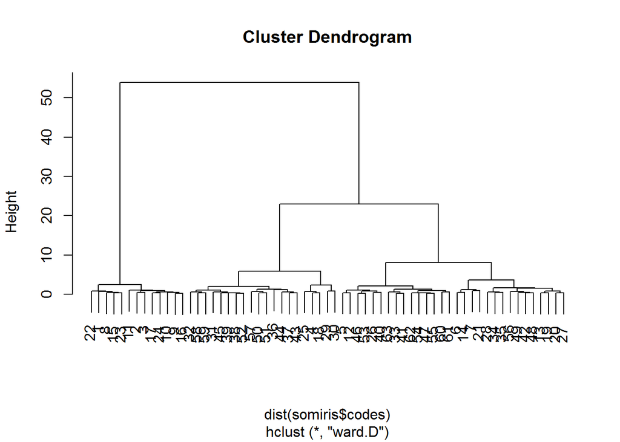

```r
par(mfrow = c(1,1))
h1 <-  hclust(dist(somiris$codes), method = "ward.D")
plot(h1)
```

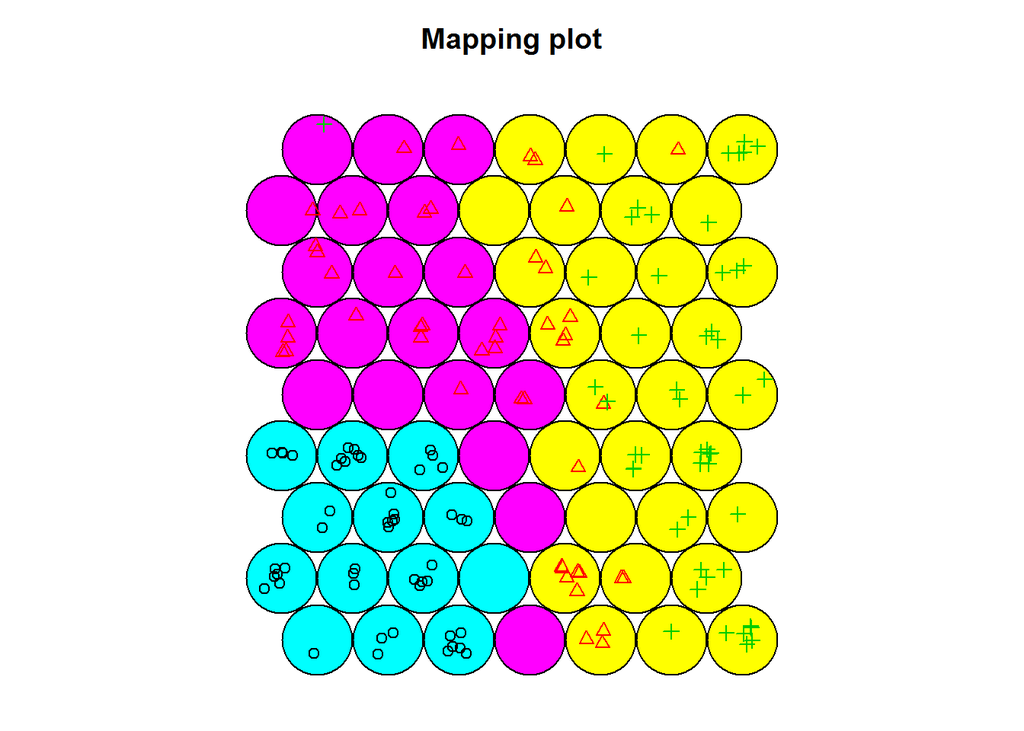

```r
plot(somiris, "mapping", pch = rep(1:3, rep (50,3)),
     col = rep(1:3, rep (50, 3)), bgcol = cutree(h1,3)+4)
```

```r
#Bgcol = background color --> Represent the groups determined by hclust

som.predict <- predict(somiris, trainY = factor(iris[,5]))
table(iris[,5], som.predict$prediction)
```

```
##
##              setosa versicolor virginica
##   setosa         50          0         0
##   versicolor      0         49         1
##   virginica       0          0        50
```

```r
AdjRkl(iris[,5], som.predict$prediction)
```

```
## [1] 0.979932
```

```r
#The method is very close to the real species
```

## Doubs

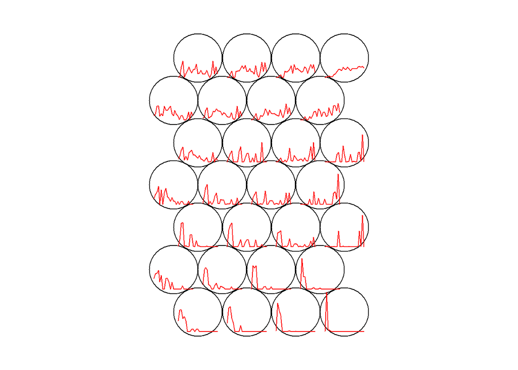

```r
set.seed(700)
somdoubs <- som(as.matrix(spe.norm), grid = somgrid(4,7,"hexagonal"))

plot(somdoubs, type = "codes")
```

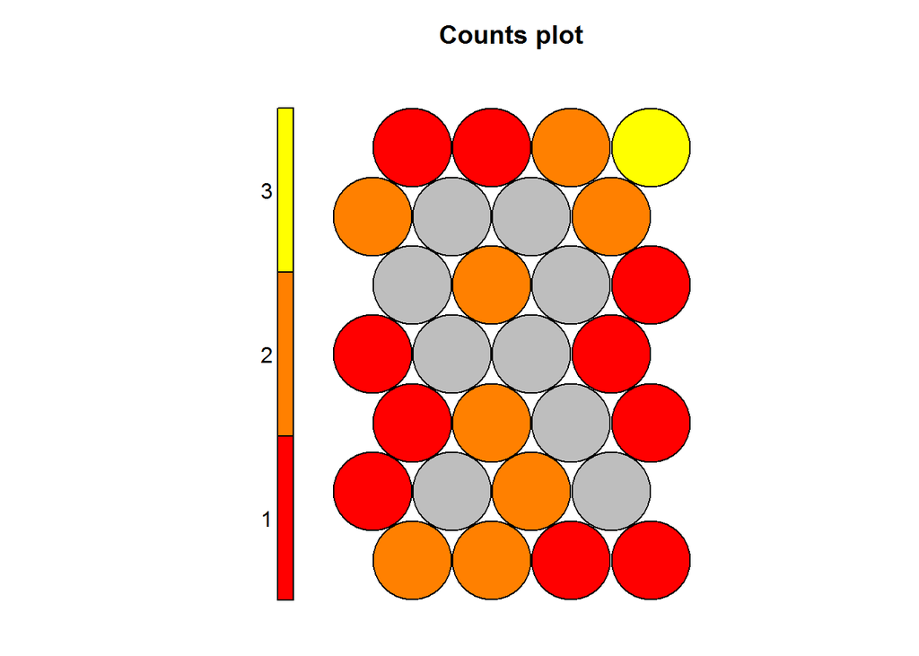

```r
plot(somdoubs, type = "counts")
```

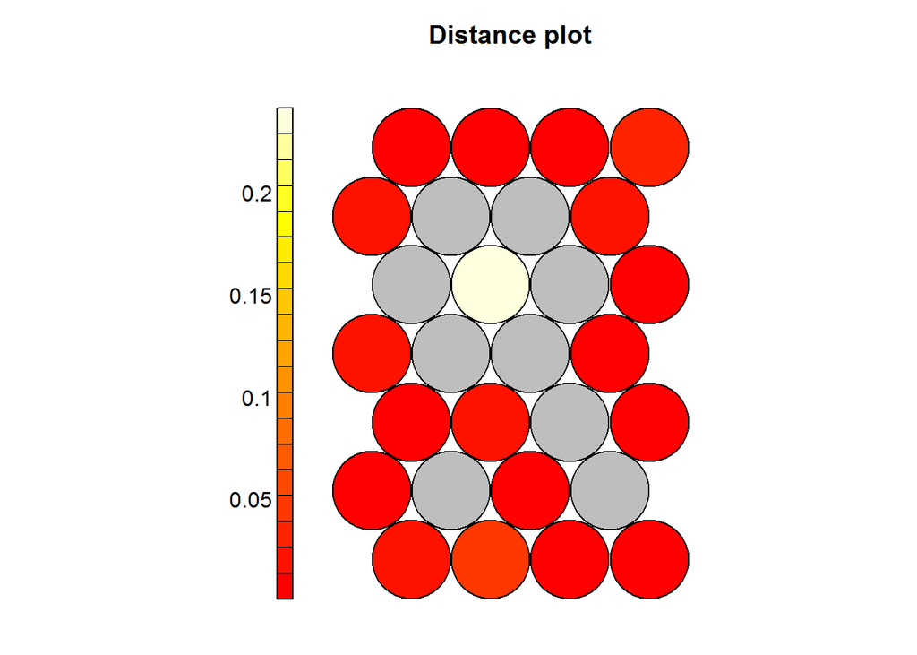

```r
plot(somdoubs, type = "quality")
```

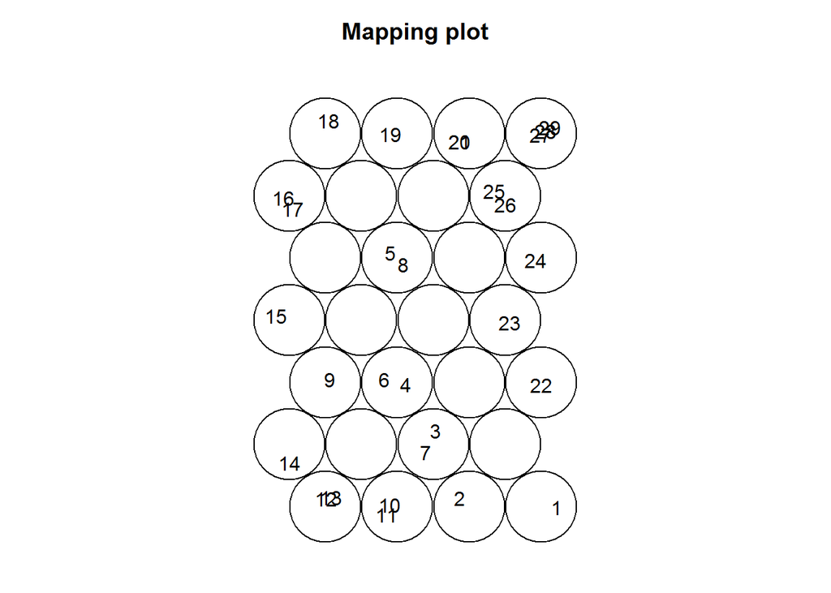

```r
plot(somdoubs, type = "mapping", labels = factor(rep(1:29,1)))
```

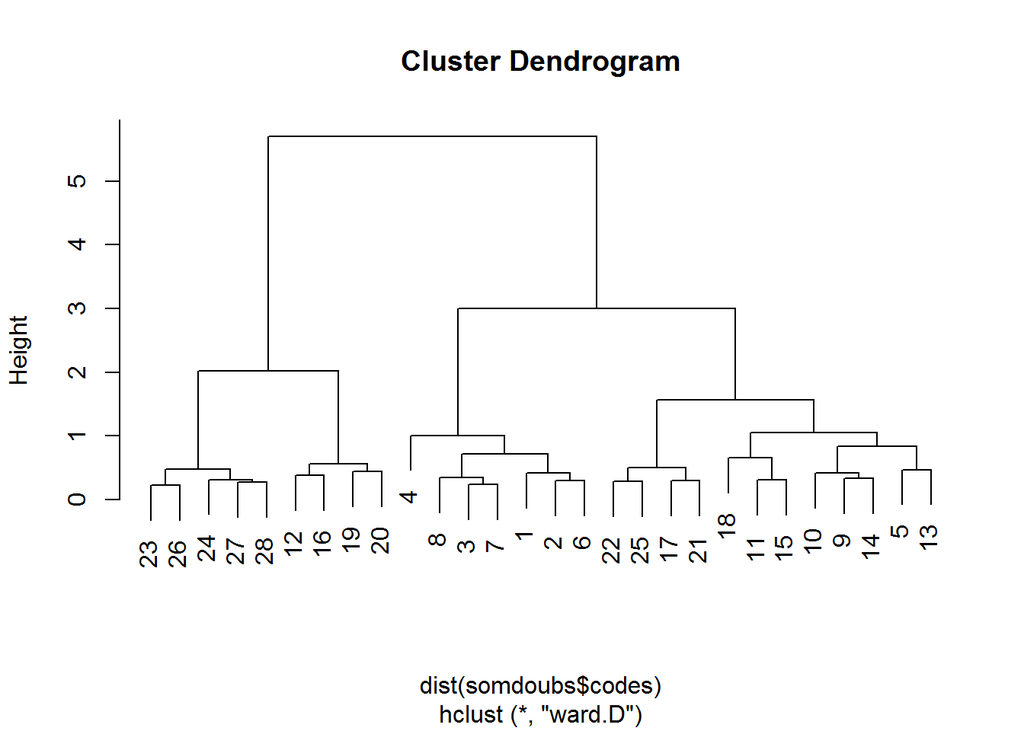

```r
par(mfrow = c(1,1))
hdoubs <-  hclust(dist(somdoubs$codes), method = "ward.D")
plot(hdoubs)
```

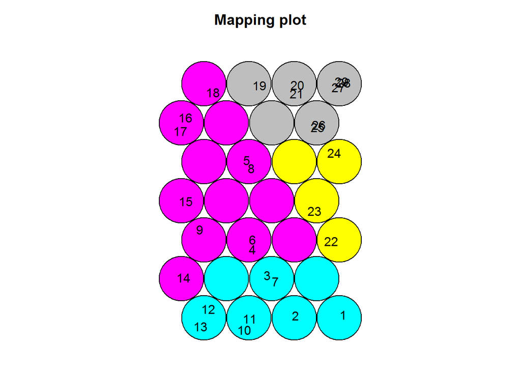

```r
plot(somdoubs, "mapping", labels = factor(rep(1:29,1)), bgcol = cutree(hdoubs,4)+4)
```

### SOM vs All

```r
som.predict.doubs.k <- predict(somdoubs, trainY = spe.kmeans$cluster)
table(spe.kmeans$cluster, som.predict.doubs.k$prediction)
```

```
##
##      1  2  3  4
##   1  6  0  0  0
##   2  0 12  0  0
##   3  0  0  8  0
##   4  0  0  0  3
```

```r
AdjRkl(spe.kmeans$cluster, som.predict.doubs.k$prediction)
```

```
## [1] 1
```

```r
som.predict.doubs.a <- predict(somdoubs, trainY = clas.agnes)
table(clas.agnes, som.predict.doubs.a$prediction)
```

```
##
## clas.agnes  1  2  3  4
##          1 11  0  0  0
##          2  0  7  0  0
##          3  0  0  8  0
##          4  0  0  0  3
```

```r
AdjRkl(clas.agnes, som.predict.doubs.a$prediction)
```

```
## [1] 1
```

```r
som.predict.doubs.d <- predict(somdoubs, trainY = clas.diana)
table(clas.diana, som.predict.doubs.d$prediction)
```

```
##
## clas.diana  1  2 2.5  3  4
##          1 14  0   0  0  0
##          2  0  2   1  0  0
##          3  0  0   1  1  0
##          4  0  0   0  0 10
```

```r
AdjRkl(clas.diana, som.predict.doubs.d$prediction)
```

```
## [1] 0.9781215
```

```r
som.predict.doubs.d <- predict(somdoubs, trainY = spe.pam$cluster)
table(spe.pam$cluster, som.predict.doubs.d$prediction)
```

```
##
##      1  2  3  4
##   1  9  0  0  0
##   2  0  5  0  0
##   3  0  0  4  0
##   4  0  0  0 11
```

```r
AdjRkl(spe.pam$cluster, som.predict.doubs.d$prediction)
```

```
## [1] 1
```

```r
som.predict.doubs.d <- predict(somdoubs, trainY = cmeans2$cluster)
table(cmeans2$cluster, som.predict.doubs.d$prediction)
```

```
##
##      1  2  3  4
##   1  9  0  0  0
##   2  0  3  0  0
##   3  0  0  7  0
##   4  0  0  0 10
```

```r
AdjRkl(cmeans2$cluster, som.predict.doubs.d$prediction)
```

```
## [1] 1
```